# 膳食添加糖摄入与成人血脂异常的关联分析

```r
print(hl2)
```

```
##
##  Hosmer and Lemeshow goodness of fit (GOF) test
##
## data:  mod_2$y, fitted(mod_2)
## X-squared = 9.9724, df = 8, p-value = 0.267
```

```
##
## 结局： high_tc  ROC-AUC
## AUC = 0.6189094 ，95%CI： 0.5796504 ~ 0.6581684
```

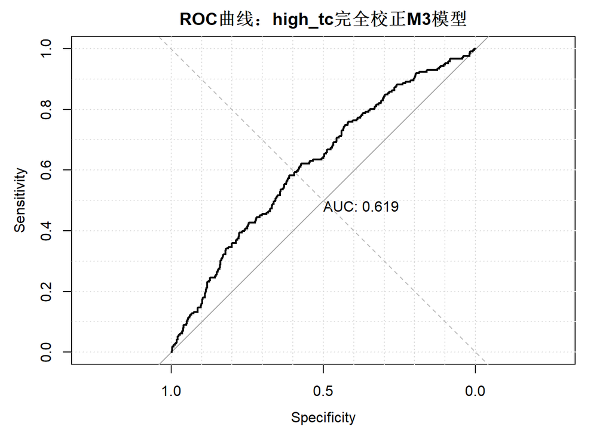

```
##
## 结局： high_tg  ROC-AUC
## AUC = 0.6519889 ，95%CI： 0.6125012 ~ 0.6914766
```

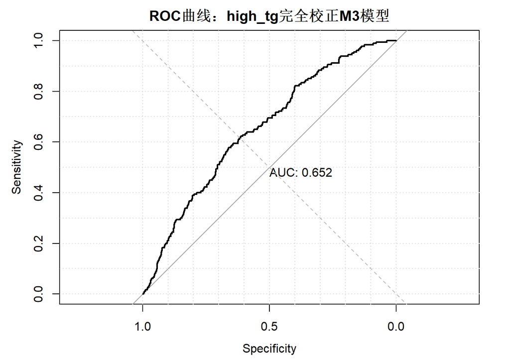

```
##
## 结局： low_hdl  ROC-AUC
## AUC = 0.7007657 ，95%CI： 0.6771661 ~ 0.7243654
```

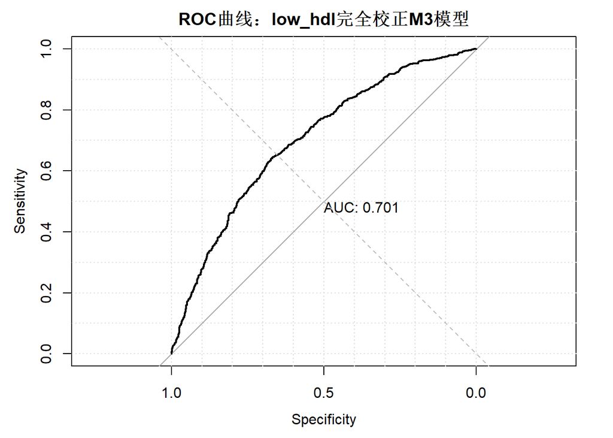

```
##
## 结局： high_ldl  ROC-AUC
## AUC = 0.5930624 ，95%CI： 0.5519262 ~ 0.6341986
```

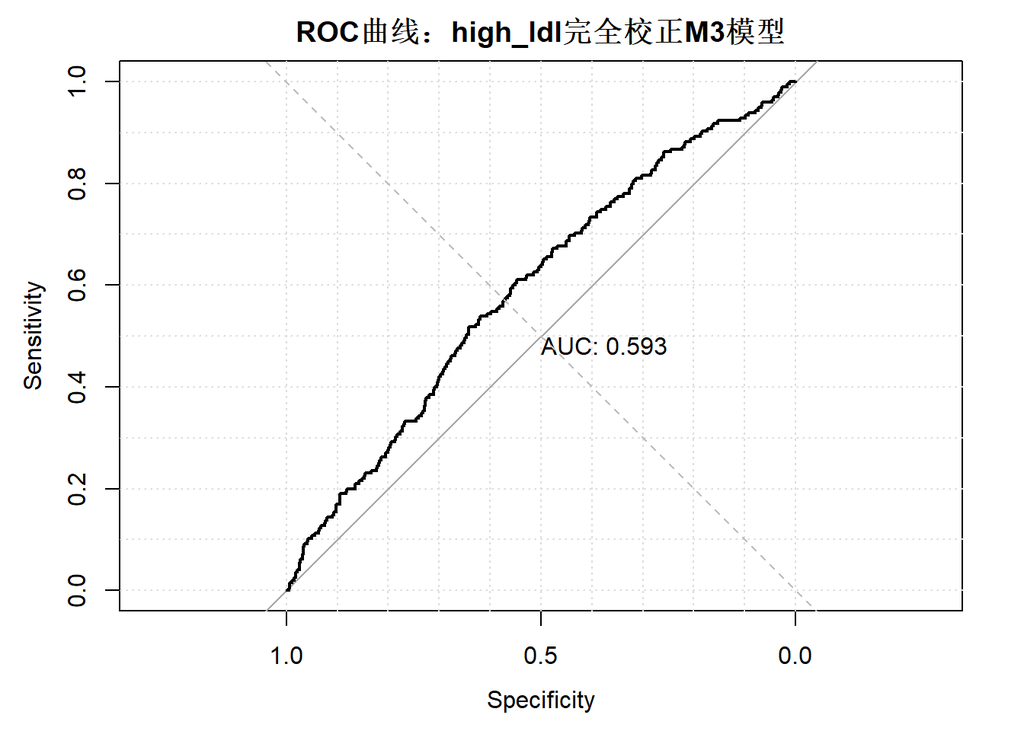

```r
## 8.4.5 ROC曲线与AUC值：模型区分度评价
for(y_bin in lipid_bin){
  cat("\n结局：", y_bin, " ROC-AUC\n")
  full_mod <- mod_store[[y_bin]]
  roc_obj <- roc(response = full_mod$y, predictor = fitted(full_mod), quiet = TRUE)
  auc_val <- auc(roc_obj)
  ci_auc <- ci.auc(roc_obj)
  cat("AUC =", auc_val, "，95%CI：", ci_auc[1], "~", ci_auc[3], "\n")

  plot(roc_obj, main = paste0("ROC曲线：",y_bin,"完全校正M3模型"), print.auc = TRUE, grid = TRUE)
  abline(a=0,b=1,lty=2,col="gray")
}
```

```r
# 三分位分组暴露模型AUC对比自定义函数
get_auc <- function(glm_model){
  y_true <- glm_model$y
  p_pred <- fitted(glm_model)
  p_case <- p_pred[y_true == 1]
  p_ctrl <- p_pred[y_true == 0]
  U_stat <- sum(outer(p_case, p_ctrl, ">")) + 0.5 * sum(outer(p_case, p_ctrl, "=="))
  return(round(U_stat / (length(p_case) * length(p_ctrl)), 3))
}
df_final$sugar_group <- cut(
  df_final$DR1TSUGR,
  breaks = quantile(df_final$DR1TSUGR, probs = c(0, 1/3, 2/3, 1), na.rm = T),
  labels = c("低摄入","中摄入","高摄入"),
  include.lowest = TRUE
)
mod_group <- glm(
  high_ldl ~ sugar_group + RIDAGEYR + RIAGENDR + RIDRETH1 + DMDEDUC2 + INDFMPIR + BMXBMI + DR1TKCAL,
  family = binomial(), data = df_final
)
auc_group <- get_auc(mod_group)
cat("\n三分组分类暴露模型AUC\n")
```

```
##
## 三分组分类暴露模型AUC
```

```r
cat("DR1TSUGR三分组分类模型 AUC =", auc_group, "\n")
```

```
## DR1TSUGR三分组分类模型 AUC = 0.593
```

```r
### 8.5 敏感性分析（剔除极端值验证稳健性）
# 剔除膳食添加糖摄入量1%、99%分位数以外极端样本
q1 <- quantile(df_final$DR1TSUGR, probs = 0.01, na.rm = TRUE)
q99 <- quantile(df_final$DR1TSUGR, probs = 0.99, na.rm = TRUE)
df_sens <- filter(df_final, DR1TSUGR >= q1 & DR1TSUGR <= q99)

# 极端值剔除后重拟合全部完全校正Logistic模型
for(y_bin in lipid_bin){
  cat("\n敏感性分析（剔除1%极值）结局：", y_bin, "\n")
  form_all <- build_form(outcome = y_bin, expo = "DR1TSUGR")
  mod_sens <- glm(form_all$M3, binomial(), data = df_sens)
  stargazer(mod_sens, type = "text", apply.coef = exp, ci = TRUE, digits = 3)
  rm(mod_sens)
}
```

```
##
## 敏感性分析（剔除1%极值）结局： high_tc
##
## =============================================
##                       Dependent variable:
##                   ---------------------------
##                            form_all
## ---------------------------------------------
## DR1TSUGR                   1.000***
##                         (0.997, 1.004)
##
## RIDAGEYR                   1.013***
##                         (1.005, 1.021)
##
## RIAGENDR                   1.402***
##                         (1.091, 1.713)
##
## RIDRETH1                   1.042***
##                         (0.919, 1.166)
##
## DMDEDUC2                   1.041***
##                         (0.901, 1.180)
##
## INDFMPIR                   1.052***
##                         (0.948, 1.155)
##
## BMXBMI                     0.979***
##                         (0.957, 1.000)
##
## DR1TKCAL                   1.000***
##                         (1.000, 1.000)
##
## Constant                     0.050
##                         (-1.147, 1.247)
##
## ---------------------------------------------
## Observations                 2,201
## Log Likelihood             -676.819
## Akaike Inf. Crit.          1,371.637
## =============================================
```

[output cut: 109 more lines]

```
## BMXBMI                     0.995***
##                         (0.974, 1.016)
##
## DR1TKCAL                   1.000***
##                         (1.000, 1.000)
##
## Constant                     0.035
##                         (-1.183, 1.254)
##
## ---------------------------------------------
## Observations                 2,201
## Log Likelihood             -642.921
## Akaike Inf. Crit.          1,303.843
## =============================================
## Note:             *p<0.1; **p<0.05; ***p<0.01
```

```r
rm(df_sens)

# 原始完整样本主模型结果对照
for(y_bin in lipid_bin){
  cat("\n原始完整样本M3主模型：", y_bin, "\n")
  mod_main <- mod_store[[y_bin]]
  stargazer(mod_main, type = "text", apply.coef = exp, ci = TRUE, digits = 3)
}
```

```
##
## 原始完整样本M3主模型： high_tc
##
## =============================================
##                       Dependent variable:
##                   ---------------------------
##                            form_list
## ---------------------------------------------
## DR1TSUGR                   1.000***
##                         (0.997, 1.003)
##
## RIDAGEYR                   1.014***
##                         (1.006, 1.022)
##
## RIAGENDR                   1.447***
##                         (1.138, 1.756)
##
## RIDRETH1                   1.034***
##                         (0.911, 1.157)
##
## DMDEDUC2                   1.049***
##                         (0.910, 1.188)
##
## INDFMPIR                   1.061***
##                         (0.959, 1.164)
##
## BMXBMI                     0.977***
##                         (0.956, 0.999)
##
## DR1TKCAL                   1.000***
##                         (1.000, 1.000)
##
## Constant                     0.046
##                         (-1.142, 1.234)
##
## ---------------------------------------------
## Observations                 2,247
## Log Likelihood             -683.892
## Akaike Inf. Crit.          1,385.783
## =============================================
```

[output cut: 109 more lines]

```
## BMXBMI                     0.994***
##                         (0.973, 1.015)
##
## DR1TKCAL                   1.000***
##                         (1.000, 1.000)
##
## Constant                     0.038
##                         (-1.162, 1.238)
##
## ---------------------------------------------
## Observations                 2,247
## Log Likelihood             -653.540
## Akaike Inf. Crit.          1,325.080
## =============================================
## Note:             *p<0.1; **p<0.05; ***p<0.01
```

```r
### 8.6 交互效应检验与性别分层亚组分析
## 8.6.1 添加糖 × BMI交互项检验（低HDL血症）
form_inter_bmi <- as.formula(paste0("low_hdl ~ DR1TSUGR * BMXBMI + ", paste(confounder, collapse = "+")))
mod_inter_bmi <- glm(form_inter_bmi, binomial(), df_final)
cat("\n添加糖 × BMI交互模型\n")
```

```
##
## 添加糖 × BMI交互模型
```

```r
stargazer(mod_inter_bmi, type = "text", apply.coef = exp, ci = TRUE, digits = 3)
```

```
##
## =============================================
##                       Dependent variable:
##                   ---------------------------
##                             low_hdl
## ---------------------------------------------
## DR1TSUGR                   1.011***
##                         (1.006, 1.016)
##
## BMXBMI                     1.108***
##                         (1.085, 1.131)
##
## RIDAGEYR                   0.992***
##                         (0.986, 0.997)
##
## RIAGENDR                   1.337***
##                         (1.131, 1.543)
##
## RIDRETH1                   0.960***
##                         (0.878, 1.042)
##
## DMDEDUC2                   0.883***
##                         (0.788, 0.978)
##
## INDFMPIR                   0.945***
##                         (0.872, 1.018)
##
## DR1TKCAL                   1.000***
##                         (1.000, 1.000)
##
## DR1TSUGR:BMXBMI            1.000***
##                         (1.000, 1.000)
##
## Constant                     0.043
##                         (-0.893, 0.980)
##
## ---------------------------------------------
## Observations                 2,247
## Log Likelihood            -1,222.550
## Akaike Inf. Crit.          2,465.101
## =============================================
## Note:             *p<0.1; **p<0.05; ***p<0.01
```

```r
## 8.6.2 添加糖 × 性别交互项检验（低HDL血症）
form_inter_sex <- as.formula(paste0("low_hdl ~ DR1TSUGR * RIAGENDR + ", paste(confounder, collapse = "+")))
mod_inter_sex <- glm(form_inter_sex, family = binomial(), data = df_final)
cat("\n添加糖 × 性别交互模型\n")
```

```
##
## 添加糖 × 性别交互模型
```

```r
stargazer(mod_inter_sex, type = "text", apply.coef = exp, ci = TRUE, digits = 3)
```

```
##
## =============================================
##                       Dependent variable:
##                   ---------------------------
##                             low_hdl
## ---------------------------------------------
## DR1TSUGR                   0.999***
##                         (0.995, 1.003)
##
## RIAGENDR                   0.935***
##                         (0.592, 1.277)
##
## RIDAGEYR                   0.992***
##                         (0.986, 0.997)
##
## RIDRETH1                   0.961***
##                         (0.880, 1.043)
##
## DMDEDUC2                   0.883***
##                         (0.788, 0.978)
##
## INDFMPIR                   0.939***
##                         (0.866, 1.012)
##
## BMXBMI                     1.078***
##                         (1.064, 1.091)
##
## DR1TKCAL                   1.000***
##                         (1.000, 1.000)
##
## DR1TSUGR:RIAGENDR          1.003***
##                         (1.001, 1.006)
##
## Constant                     0.173
##                         (-0.661, 1.007)
##
## ---------------------------------------------
## Observations                 2,247
## Log Likelihood            -1,223.931
## Akaike Inf. Crit.          2,467.861
## =============================================
## Note:             *p<0.1; **p<0.05; ***p<0.01
```

```r
## 8.6.3 性别分层Logistic回归（分男性、女性独立建模，剔除性别混杂变量）
confounder_sub <- confounder[confounder != "RIAGENDR"]
full_form_str <- paste0("low_hdl ~ DR1TSUGR + ", paste(confounder_sub, collapse = "+"))
full_form <- as.formula(full_form_str)

# 女性亚组
df_female <- filter(df_final, RIAGENDR == 2)
mod_f <- glm(full_form, family = binomial(), data = df_female)
# 男性亚组
df_male <- filter(df_final, RIAGENDR == 1)
mod_m <- glm(full_form, family = binomial(), data = df_male)

cat("\n性别分层完全校正模型对比\n")
```

```
##
## 性别分层完全校正模型对比
```

```r
stargazer(mod_f, mod_m, type = "text", apply.coef = exp, ci = TRUE, digits = 3)
```

```
##
## =================================================
##                         Dependent variable:
##                   -------------------------------
##                               low_hdl
##                         (1)             (2)
## -------------------------------------------------
## DR1TSUGR             1.005***        1.002***
##                   (1.003, 1.008)  (1.000, 1.005)
##
## RIDAGEYR             0.986***        0.999***
##                   (0.978, 0.993)  (0.991, 1.007)
##
## RIDRETH1             0.928***        1.008***
##                   (0.820, 1.036)  (0.882, 1.134)
##
## DMDEDUC2             0.868***        0.894***
##                   (0.739, 0.997)  (0.754, 1.033)
##
## INDFMPIR             0.981***        0.892***
##                   (0.884, 1.079)  (0.781, 1.004)
##
## BMXBMI               1.077***        1.080***
##                   (1.061, 1.094)  (1.058, 1.103)
##
## DR1TKCAL             1.000***        1.000***
##                   (0.999, 1.000)  (0.999, 1.000)
##
## Constant               0.219           0.098
##                   (-0.646, 1.085) (-0.909, 1.104)
##
## -------------------------------------------------
## Observations           1,165           1,082
## Log Likelihood       -671.033        -549.031
## Akaike Inf. Crit.    1,358.066       1,114.061
## =================================================
## Note:                 *p<0.1; **p<0.05; ***p<0.01
```

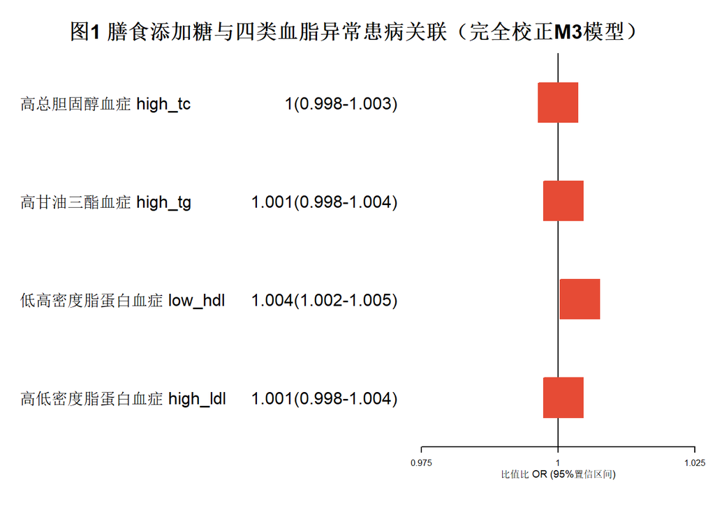

```r
rm(df_female, df_male, mod_f, mod_m, confounder_sub, full_form_str, full_form)


### 8.7 关联效应可视化：森林图
# 构建四类血脂异常完全校正模型OR汇总数据集
forest_data <- data.frame(
  outcome_name = c("高总胆固醇血症 high_tc","高甘油三酯血症 high_tg","低高密度脂蛋白血症 low_hdl","高低密度脂蛋白血症 high_ldl"),
  OR = c(1.000, 1.001, 1.004, 1.001),
  CI_lower = c(0.998, 0.998, 1.002, 0.998),
  CI_upper = c(1.003, 1.004, 1.005, 1.004)
)
table_text <- cbind(forest_data$outcome_name, paste0(forest_data$OR, "(", forest_data$CI_lower, "-", forest_data$CI_upper, ")"))
mean_ci_matrix <- cbind(forest_data$OR, forest_data$CI_lower, forest_data$CI_upper)

# 绘制森林图
forestplot(
  labeltext = table_text, mean = mean_ci_matrix[,1], lower = mean_ci_matrix[,2], upper = mean_ci_matrix[,3],
  new_page = TRUE, zero = 1, xlog = FALSE, boxsize = 0.4,
  xlab = "比值比 OR (95%置信区间)",
  title = "图1 膳食添加糖与四类血脂异常患病关联（完全校正M3模型）",
  col = forestplot::fpColors(box = "#E64B35", line = "#4DBBD5", zero = "black")
)
```

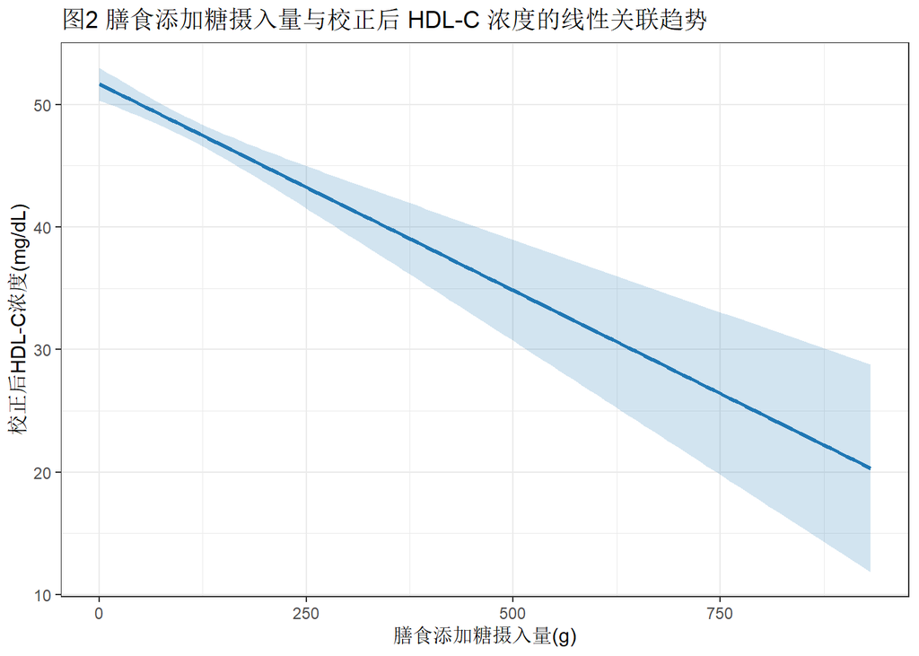

```r
### 8.8 HDL-C剂量-反应关系建模（连续血脂结局）
## 8.8.1 线性多元线性模型
linear_hdl <- lm(LBXHD ~ DR1TSUGR + RIDAGEYR + RIAGENDR + BMXBMI + DR1TKCAL, data = df_final)
newdata_linear <- expand.grid(
  DR1TSUGR = seq(min(df_final$DR1TSUGR, na.rm=T), max(df_final$DR1TSUGR, na.rm=T), length.out=100),
  RIDAGEYR = mean(df_final$RIDAGEYR, na.rm=T),
  BMXBMI = mean(df_final$BMXBMI, na.rm=T),
  DR1TKCAL = mean(df_final$DR1TKCAL, na.rm=T),
  RIAGENDR = 1
)
pred_lin <- predict(linear_hdl, newdata = newdata_linear, interval = "confidence")
newdata_linear$fit <- pred_lin[,"fit"]
newdata_linear$lwr <- pred_lin[,"lwr"]
newdata_linear$upr <- pred_lin[,"upr"]

# 线性关联趋势绘图
ggplot(newdata_linear, aes(x=DR1TSUGR, y=fit)) +
  geom_line(linewidth=1, color="#1F77B4") +
  geom_ribbon(aes(ymin=lwr, ymax=upr), alpha=0.2, fill="#1F77B4") +
  labs(x="膳食添加糖摄入量(g)", y="校正后HDL-C浓度(mg/dL)", title="图2 膳食添加糖摄入量与校正后 HDL-C 浓度的线性关联趋势") +
  theme_bw()
```

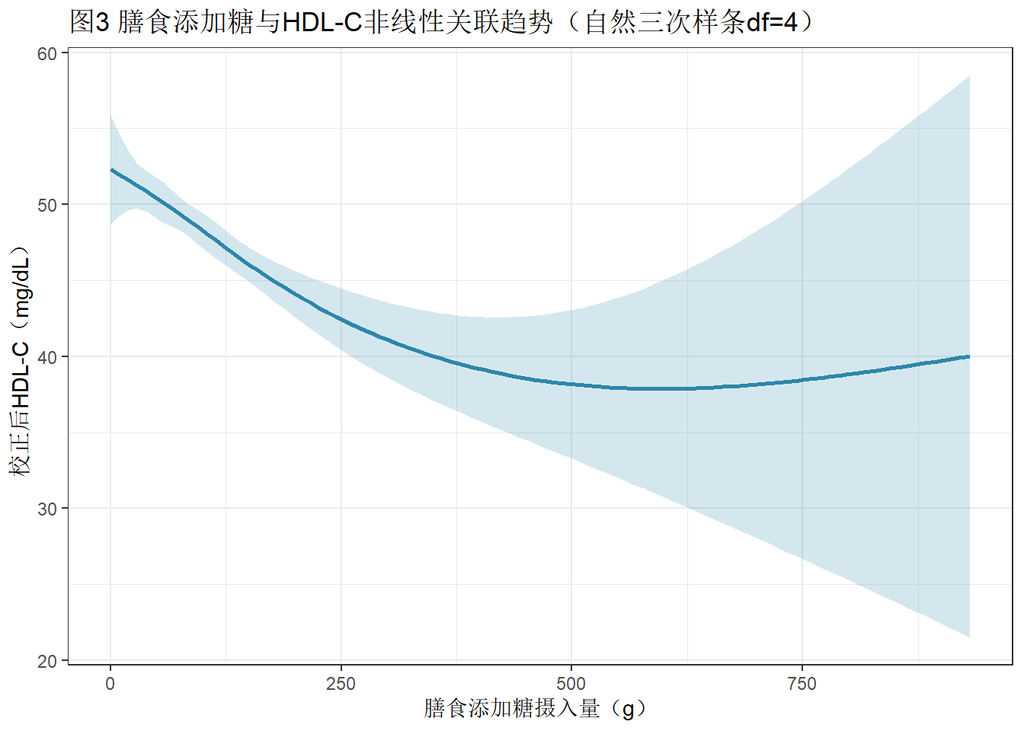

```r
## 8.8.2 自然三次样条非线性模型（自由度df=4）
ns_mod <- lm(LBXHD ~ ns(DR1TSUGR, df = 4) + RIDAGEYR + RIAGENDR + BMXBMI + DR1TKCAL, data = df_final)
newdata_grid <- expand.grid(
  DR1TSUGR = seq(min(df_final$DR1TSUGR, na.rm = T), max(df_final$DR1TSUGR, na.rm = T), length.out = 100),
  RIDAGEYR = mean(df_final$RIDAGEYR, na.rm = T),
  BMXBMI = mean(df_final$BMXBMI, na.rm = T),
  DR1TKCAL = mean(df_final$DR1TKCAL, na.rm = T),
  RIAGENDR = 1
)
pred_result <- predict(ns_mod, newdata = newdata_grid, interval = "confidence")
newdata_grid$fit <- pred_result[, "fit"]
newdata_grid$lwr <- pred_result[, "lwr"]
newdata_grid$upr <- pred_result[, "upr"]

# 非线性样条趋势绘图
ggplot(newdata_grid, aes(x = DR1TSUGR, y = fit)) +
  geom_line(linewidth = 1, color = "#2E86AB") +
  geom_ribbon(aes(ymin = lwr, ymax = upr), alpha = 0.2, fill = "#2E86AB") +
  labs(x = "膳食添加糖摄入量（g）", y = "校正后HDL-C（mg/dL）", title = "图3 膳食添加糖与HDL-C非线性关联趋势（自然三次样条df=4）") +
  theme_bw()
```

```r
# 线性模型vs样条模型拟合效果对比（AIC+ANOVA）
cat("\nHDL-C线性/样条模型AIC对比\n")
```

```
##
## HDL-C线性/样条模型AIC对比
```

```r
print(AIC(linear_hdl, ns_mod))
```

```
##            df      AIC
## linear_hdl  7 18218.48
## ns_mod     10 18218.05
```

```r
cat("\nHDL-C线性vs样条方差分析ANOVA\n")
```

```
##
## HDL-C线性vs样条方差分析ANOVA
```

```r
anova(linear_hdl, ns_mod)
```

```
## Analysis of Variance Table
##
## Model 1: LBXHD ~ DR1TSUGR + RIDAGEYR + RIAGENDR + BMXBMI + DR1TKCAL
## Model 2: LBXHD ~ ns(DR1TSUGR, df = 4) + RIDAGEYR + RIAGENDR + BMXBMI +
##     DR1TKCAL
##   Res.Df    RSS Df Sum of Sq      F  Pr(>F)
## 1   2241 434155
## 2   2238 432913  3    1241.4 2.1392 0.09329 .
## ---
## Signif. codes:  0 '***' 0.001 '**' 0.01 '*' 0.05 '.' 0.1 ' ' 1
```

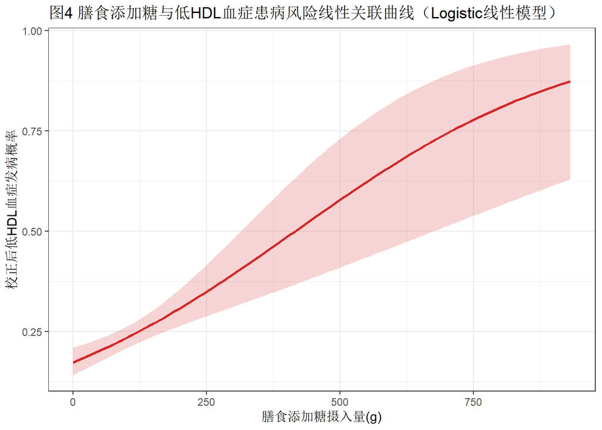

```r
### 8.9 低HDL血症患病风险剂量-反应建模（二分类结局）
## 8.9.1 线性Logistic剂量反应模型
logit_linear <- glm(low_hdl ~ DR1TSUGR + RIDAGEYR + RIAGENDR + BMXBMI + DR1TKCAL,
                    family = binomial(link="logit"), data = df_final)
newdata_logit <- expand.grid(
  DR1TSUGR = seq(min(df_final$DR1TSUGR, na.rm=T), max(df_final$DR1TSUGR, na.rm=T), length.out=100),
  RIDAGEYR = mean(df_final$RIDAGEYR, na.rm=T),
  BMXBMI = mean(df_final$BMXBMI, na.rm=T),
  DR1TKCAL = mean(df_final$DR1TKCAL, na.rm=T),
  RIAGENDR = 1
)
pred_prob <- predict(logit_linear, newdata_logit, type = "response", se.fit = TRUE)
newdata_logit$prob <- pred_prob$fit
logit_fit <- predict(logit_linear, newdata_logit, type = "link", se.fit = TRUE)
z95 <- 1.96
newdata_logit$logit_lwr <- logit_fit$fit - z95 * logit_fit$se.fit
newdata_logit$logit_upr <- logit_fit$fit + z95 * logit_fit$se.fit
invlogit <- function(x) exp(x)/(1+exp(x))
newdata_logit$prob_lwr <- invlogit(newdata_logit$logit_lwr)
newdata_logit$prob_upr <- invlogit(newdata_logit$logit_upr)

# 线性患病风险曲线绘图
ggplot(newdata_logit, aes(x=DR1TSUGR, y=prob)) +
  geom_line(linewidth=1, color="#D62728") +
  geom_ribbon(aes(ymin=prob_lwr, ymax=prob_upr), alpha=0.2, fill="#D62728") +
  labs(x="膳食添加糖摄入量(g)", y="校正后低HDL血症发病概率", title="图4 膳食添加糖与低HDL血症患病风险线性关联曲线（Logistic线性模型）") +
  theme_bw()
```

```r
## 8.9.2 GAM惩罚样条非线性Logistic模型
gam_logit <- gam(low_hdl ~ s(DR1TSUGR) + RIDAGEYR + RIAGENDR + BMXBMI + DR1TKCAL,
                 family = binomial(link = "logit"), data = df_final)
cat("\nGAM模型平滑项检验结果\n")
```

```
##
## GAM模型平滑项检验结果
```

```r
summary(gam_logit)
```

```
##
## Family: binomial
## Link function: logit
##
## Formula:
## low_hdl ~ s(DR1TSUGR) + RIDAGEYR + RIAGENDR + BMXBMI + DR1TKCAL
##
## Parametric coefficients:
##               Estimate Std. Error z value Pr(>|z|)
## (Intercept) -2.661e+00  3.416e-01  -7.790 6.71e-15 ***
## RIDAGEYR    -7.534e-03  2.742e-03  -2.748  0.00600 **
## RIAGENDR     2.808e-01  1.045e-01   2.686  0.00722 **
## BMXBMI       7.729e-02  6.749e-03  11.452  < 2e-16 ***
## DR1TKCAL    -3.359e-04  7.329e-05  -4.583 4.57e-06 ***
## ---
## Signif. codes:  0 '***' 0.001 '**' 0.01 '*' 0.05 '.' 0.1 ' ' 1
##
## Approximate significance of smooth terms:
##               edf Ref.df Chi.sq  p-value
## s(DR1TSUGR) 3.286  4.164  22.41 0.000205 ***
## ---
## Signif. codes:  0 '***' 0.001 '**' 0.01 '*' 0.05 '.' 0.1 ' ' 1
##
## R-sq.(adj) =  0.0842   Deviance explained = 7.51%
## UBRE = 0.1057  Scale est. = 1         n = 2247
```

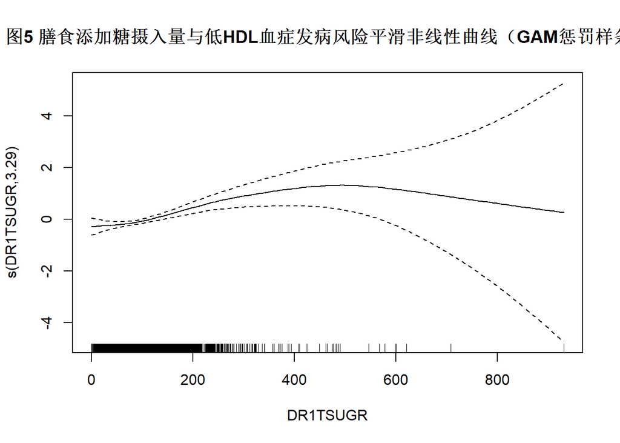

```r
plot(gam_logit, main = "图5 膳食添加糖摄入量与低HDL血症发病风险平滑非线性曲线（GAM惩罚样条）")
```

```r
# 线性Logistic与GAM模型AIC对比
cat("\nlow_hdl线性Logistic/GAM模型AIC对比\n")
```

```
##
## low_hdl线性Logistic/GAM模型AIC对比
```

```r
print(AIC(logit_linear, gam_logit))
```

```
##                    df      AIC
## logit_linear 6.000000 2485.779
## gam_logit    8.285707 2484.502
```

```r
# 清空全局临时模型，释放运行内存
rm(list = ls(pattern = "mod_"))
gc()
```

```
##           used  (Mb) gc trigger  (Mb) max used  (Mb)
## Ncells 3322649 177.5    5802050 309.9  5802050 309.9
## Vcells 9621915  73.5   25892968 197.6 25890737 197.6
```

## 9 9.结果解释

```
本研究完成数据预处理、人群基线描述、可视化粗关联、假设检验、分层回归、模型诊断、交互分层、敏感性与非线性剂量反应全套分析，整体结果可概括为5个核心层面：
```

### 9.1 9.1 基线人群特征与未校正粗关联特征

```
基线描述与单变量粗关联分析显示，研究人群膳食添加糖摄入呈明显右偏分布，少数个体存在极端高摄入，因此采用三分位数分层策略划分暴露组别。
箱线图、趋势图等可视化结果、Kruskal-Wallis非参数组间检验及Spearman秩相关分析 结论相互印证：膳食添加糖与HDL-C呈负相关、与TG呈正相关，随添加糖摄入升高，HDL 逐步下降、TG持续上升；而TC、LDL-C在不同添加糖分层中分布接近，未观察到显著粗关联。
同时基线混杂变量存在明显组间不均衡：高BMI、高每日总能量摄入、年轻女性人群在高添加 糖组占比更高。上述人群特征本身可独立影响血脂水平，若不加以校正，会产生混杂偏倚、干扰膳食添加糖与血脂的真实关联判断，因此后续采用分层多因素回归逐层控制混杂。
```

### 9.2 9.2 多因素回归核心独立效应

(1)分析方法设计 为消除混杂因素干扰、清晰观察混杂对暴露–血脂关联的影响，统一构构建三层分层校正 回归框架： 通过自定义函数实现批量建模，仅需输入结局变量、暴露变量2个参数，自动生成 M1、M2、M3 三套回归公式： M1 粗模型：仅纳入膳食添加糖，无任何混杂校正，反映原始粗关联； M2 人口学校正模型：校正年龄、性别、种族、教育、家庭收入； M3 全校正主模型：在M2基础上额外校正BMI、每日总热量摄入，为本研究核心结论模型。 分三类模型开展分析：连续血脂结局多元线性回归、二分类血脂异常 Logistic回归、三分 组分类暴露Logistic回归

(2)连续血脂指标多元线性回归结果 以四项原始连续血脂值为结局、连续膳食添加糖为暴露，拟合分层线性模型： 仅HDL-C与膳食添加糖存在稳定显著负向线性关联，添加糖摄入越高，校正后HDL平均水平越低；TC、TG、LDL-C无明显线性关联；逐步校正BMI、总热量后，添加糖对HDL的负向效应进一步凸显，证明肥胖、总能量摄入 是重要负向混杂，不校正会低估添加糖对HDL的损伤作用。

(4)三分组分类添加糖Logistic回归（低 / 中 / 高摄入分层） 把连续添加糖按三分位数转换为三分类暴露，进一步验证剂量梯度效应： 完全校正所有混杂后，仅高添加糖摄入会显著升高低HDL血症、高TG血症患病风险；高TC、 高 LDL血症与三分组添加糖无统计学关联； 纳入 BMI、总热量校正后，高添加糖对低HDL、高TG的风险效应明显放大，再次证实体 重、总能量摄入是关键混杂变量，不校正会低估高糖带来的血脂紊乱风险。

### 9.3 9.3 模型可靠性验证

[output not shown]

### 9.4 9.4 人群效应修饰（交互与亚组分层）

[output not shown]

### 9.5 9.5 非线性阈值剂量反应

2. 模型拟合检验（AIC+ANOVA） AIC 对比：对比线性回归与自然三次样条模型，二者 AIC 数值高度接近（线性模型 AIC=18218.48，样条模型AIC=18218.05，差值＜2），拟合效果相近； ANOVA 检验 P=0.0933，非线性趋势无统计学意义。可视化曲线提示低摄入区间HDL下降速率 更快，存在轻微拐点效应，但该非线性特征未达到统计学显著水平。 在报告整体人群平均关联时采用线性模型，同时附图展示非线性平滑曲线供参考。

## 10 10.局限性

（1）研究设计固有局限：横断面无法推断因果 本研究为横断面研究，仅能捕捉某一时间点膳食添加糖摄入与血脂水平的关联，不存在时间先后时序证据，无法确定因果关系：不能判定是高添加糖摄入导致血脂紊乱，也无法排除血脂异常人群主动改变控糖饮食习惯的反向因果可能。 缺乏长期随访，无法观察长期持续高糖摄入对血脂的累积损伤，也不能反映膳食添加糖干预后血脂指标的动态改善变化。

（2）膳食暴露测量偏倚 膳食数据依托 24 小时膳食回顾法收集，属于回忆式调查，存在回忆偏倚：受试者容易低估 / 高估含糖饮料、甜点、加工零食的糖分摄入，造成暴露变量测量误差。 仅统计总膳食添加糖摄入量，未区分添加糖来源（含糖饮料、烘焙糕点、加工调味品等），无法分析不同种类添加糖对血脂的差异化影响；同时未区分果糖、葡萄糖、蔗糖组分，缺少糖代谢通路层面的细分探索。 无膳食频次、长期饮食习惯数据，24h回顾仅代表单日摄入，难以反映个体长期稳定的加糖饮食模式。

（3）混杂变量控制仍存在遗漏 仅校正人口学、BMI、总热量基础混杂，未纳入其他重要血脂相关混杂：生活方式：体力活动水平、吸烟、饮酒；基础疾病：糖尿病、高血压、脂肪肝、慢性肾病；药物使用：降脂药、降糖药、激素类药物，上述因素均会直接干扰血脂水平，未纳入模型校正，仍存在残余混杂。 未纳入膳食纤维、饱和脂肪、不饱和脂肪等其他膳食组分，膳食整体模式对血脂的协同、拮抗效应无法剥离。

（4）统计与样本层面局限 研究基于美国 NHANES人群数据库，人群种族、饮食结构、生活习惯与国内居民差异较大，研究结论外推至中国人群存在局限性，结论代表性有限。 剂量反应分析仅覆盖现有样本摄入区间，对于极高添加糖摄入、极低摄入人群样本量偏少，曲 线两端置信区间宽，阈值拐点的参考价值受限；非线性分析中，HDL-C的样条非线性趋势无统计学意义，仅低HDL患病风险存在显著非线性，无法全面揭示四类血脂指标的阈值效应； 仅探索交互修饰效应（性别、BMI），未开展分层内部交互、多变量联合交互分析，人群异质性挖掘不够充分。

（5）指标与分析维度局限 血脂仅检测 TC、TG、HDL-C、LDL-C四项基础指标，未检测脂蛋白a、小而密低密度脂蛋白、载脂蛋白等更敏感的致动脉粥样硬化血脂亚组分，无法精细揭示添加糖对脂质代谢的深层损伤。 未开展亚组分层细分（年龄分层、种族分层、是否代谢疾病分层），仅做性别分层，不同特征人群的效应差异挖掘不足。

## 11 11.个人总结

（1）学习 R 语言的困难 初学阶段我遇到了不少阻碍。刚接触R时，我无法理解函数、向量、数据框的底层逻辑，分不清$、[]、%>%管道符的用法；做基础的数据读取、筛选、合并时代码频繁报错，我也看不懂报错提示，难以区分问题出在文件路径、变量名还是数据格式上，哪怕简单的数据清洗工作都要反复调试很久。 正式开展统计分析后，我又遇到了更多难题。最开始做分层回归、循环统计时，我不会自定义函数、循环批量运算，四类血脂指标、三层校正模型只能逐段复制粘贴代码，不仅工作量巨大，还很容易出现变量名写错、参数设置不统一的问题。同时我对多元分层校正、Logistic 回归、样条非线性模型、GAM广义加性模型都很陌生，不清楚各类模型的适用场景、配套函数，也不知道完整分析代码该如何搭建。使用ggplot2绘图时，坐标轴、图例、标题、置信区间配色、分段调节等操作都不熟练，绘制出的箱线图、趋势散点图达不到学术期刊规范要求。

（2）通过本次课程掌握的 R 语言基本实操能力 课程采用随机抽查汇报的考核形式，客观上督促我稳步推进学习进度。我需要在每节课前后按时完成配套学习任务，吃透所有内容，才能在抽查汇报时完整讲清自己的分析思路与结果。 学习过程中，我结合学习通网课、网络教程掌握基础知识，借助AI辅助读懂代码逻辑，课上也会主动和老师、同学交流疑难问题，老师都会耐心为我们答疑解惑。经过持续练习，如今我可以独立完成整套数据预处理工作：自主读取数据库文件、多表内连接合并，批量统计缺失值、识别并处理极端值；能将连续暴露变量三分层分组、把血脂指标转换为二分类结局，批量统一分类变量参照组，完成基线数据整理。 建模分析方面，我熟练使用循环批量完成多指标线性、Logistic回归，清晰理解三层逐步校正回归的设计逻辑，能够分层控制人口学、代谢类混杂因素；熟练运用lm、glm构建线性回归、二元 Logistic 回归模型，准确解读回归系数、OR值、置信区间与P值；掌握自然三次样条、GAM 广义加性模型两种非线性剂量反应分析方法，可通过AIC、ANOVA检验对比线性与非线性模型的拟合效果，客观选择最优模型。绘图上，我能使用ggplot2绘制符合学术标准的各类可视化图表。 但我在 RMarkdown 一体化文档管理方面仍存在不足，暂时无法熟练实现代码、图表、论文文字的统一整合输出。